# Data605_hw13_wzhou

Wei Zhou

11/23/2019

### Q1

Use integration by substitution to solve the integral below.

$\int{4e^{-7x}dx}$

Answer:

Let $U=-7x$ , then $dU = -7dx$ $dx = \frac{dU}{-7}$

$$\begin{split}
\int{4e^{-7x}dx} &= \int{4e^{-7x}\frac{dU}{-7}} \\
&= \int{\frac{4}{-7}e^udU}\\
&= \frac{-4}{7}e^u+constant \\
&= -\frac{4}{7}e^{-7x}+ constant
\end{split}$$

### Q2

Biologists are treating a pond contaminated with bacteria. The level of contamination is changing at a rate of $\frac{dN}{dt} = -\frac{3150}{t^4}-220$ bacteria per cubic centimeter per day, where $t$ is the number of days since treatment began. Find a function $N(t)$ to estimate the level of contamination if the level after $1$ day was $6530$ bacteria per cubic centimeter.

Answer:
$$\frac{dN}{dt} = N'(t) = \frac{-3150}{t^4}-220 \\
N(t) = \int{(\frac{-3150}{t^4}-220) dt} = \frac{1050}{t^3}-220t+C$$

Let $t=1$ and $N(1)= 6530$, then

$$\begin{split}
N(t) &= \frac{1050}{t^3}-220t+C \\
N(1) &= 6530 \\
\frac{1050}{1^3}-220\times 1 +C &= 6530 \\
C &= 6530 - 1050 + 220 \\
C &= 5700
\end{split}$$

Now we get the contamination formula: $N(t) = \frac{1050}{t^3}-220t+5700$

### Q3

Answer:

A more elegant and more universal solution can be produced using integral.

$Area = \int_{4.5}^{8.5}{(2x-9)dx} = 16$

It is important to note that the line cuts off a quarter of a unit square from each rectangle. These little triangles above the line are the same as the missing triangles below the line, so the area of all rectangles is equal to the area under the line from $4.5$ (where the line intersects the $x$ axis) to $8.5$ (the right side of the last rectangle).

### Q4

Find the area of the region bounded by the graphs of the given equations.

$y_1 = x_1^2 - 2x_1-2$

$y_2 = x_2 + 2$

Answer:

Function visualization:

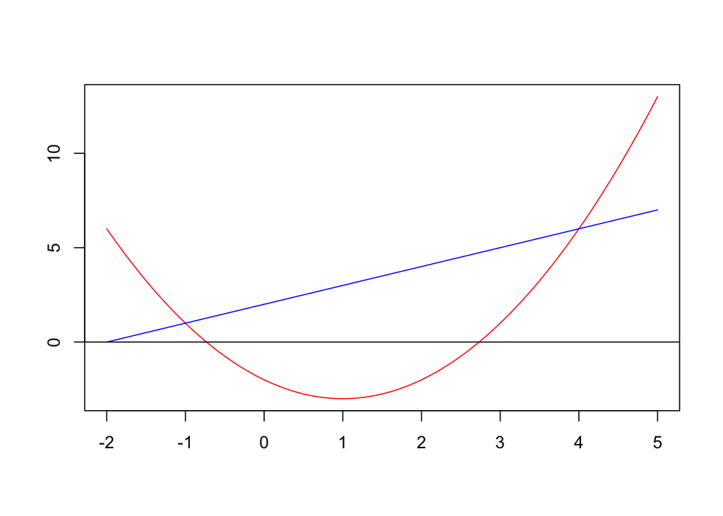

```r
eq1 <- function(x) x^2-2*x-2
eq2 <- function(x) x+2
min <- -2
max <- 5
x1 <- seq(min, max, 0.01)
plot(x1, eq1(x1), type='l', col="red",
     xlab="", ylab="")
lines(x1, eq2(x1), col="blue")
abline(h=0)
```

Because the quadratic function dips below the $x$ axis, we need 4 points to evaluate the integrals and find the area - intersections of two functions and roots of the quadratic function. Let us find the intersection of two functions. They intersect where $f_1(x)-f_2(x)=0$.
$$\begin{split}
(x^2-2x-2)-(x+2)=0
&= x^2-3x-4=0
\end{split}$$

Now, we know the function intersect with each other when x=-1 or x=4

To calculate the area bounded by the two function when x between -1 and 4:

$$\int _{ -1 }^{ 4 }{ (x+2)-(x^{2}-2x-2) } dx\\
\int _{ -1 }^{ 4 } {(x+2-x^{2}+2x+2)dx}\\
\int _{- 1 }^{ 4 } {(-x^{2}+3x+4)dx}$$

```r
integrand <- function(x)
  {
  -x^{2}+3*x+4
  }

integrate(integrand, lower = -1, upper = 4)
```

```
## 20.83333 with absolute error < 2.3e-13
```

### Q5

A beauty supply store expects to sell 110 flat irons during the next year. It costs $3.75 to store one flat iron for one year. There is a fixed cost of $8.25 for each order. Find the lot size and the number of orders per year that will minimize inventory costs.

Answer We let x be the number of flat irons per order.

The number of orders is found from the ratio 110/x.

The yearly ordering cost is the number of flat irons expected to be sold multiplied by the fixed cost per order, divded by the number of flat irons (8.25(110))/x

The cost function is assembled from all of these pieces.

We need to derive C(x) and set c’(x)=o, to find the ciritcal points. Once we find the ciritcal points, we determine which one minimizes C(x)

$$0=1.86-\frac{907.5}{x^{2}}\\
\frac{907.5}{x^{2}}=1.86\\
907.7=1.86 x^{2}\\
488.0108=x^{2}\\
+22.09097=x\\
-22.09097=x$$
Reject the negative:
$$+22.09097=x$$
Round this to 22. Apply second derivative test to check if this is indeed a minimum. We need to evaluate C’’(x)
$$C ''(x)=\frac{907.5}{x^{3}}\\
C''(22)=\frac{907.5}{22^{3}}>0$$
22 flat irons and 5 orders per year minimizes cost

### Q6

Use integration by parts to solve the integral below.

$\int{ln(9x) \times x^6 dx}$

Answer:

Let $u= ln(9x)$, then we get $\frac{du}{dx}=\frac{1}{x}$.

Let $\frac{dv}{dx}=x^6$, then $v = \int{x^6 dx} = \frac{1}{7}x^7$.

Based on: $\int{u \frac{dv}{dx}dx} = uv - \int{v \frac{du}{dx} dx}$

$$\begin{split}
\int{ln(9x) \times x^6 dx} &= \frac{1}{7}x^7 \times ln(9x) - \int{\frac{1}{7}x^7 \times \frac{1}{x} dx} \\
&=\frac{1}{7}x^7 \times ln(9x) - \int{\frac{1}{7}x^6 dx} \\
&=\frac{7}{49}x^7 \times ln(9x) - \frac{1}{49}x^7 + c \\
&=\frac{1}{49}x^7 (7ln(9x) - 1) + c \\
\end{split}$$

### Q7

Determine whether $f(x)$ is a probability density function on the interval $[1, e^6]$. If not, determine the value of the definite integral.

$f(x) = \frac{1}{6x}$

Answer:
$$\begin{split}
\int_1^{e^6}\frac{1}{6x} dx &= \frac{1}{6} ln(x)|_1^{e^6} \\
&= \frac{1}{6} ln(e^6) - \frac{1}{6} ln(1) \\
&= \frac{1}{6} \times 6 - \frac{1}{6} \times 0 \\
&= 1
\end{split}$$
The definite integral of the function on interval $[1, e^6]$ is $1$.

Additionally, if $x>0$, then $f(x)>0$, so for this interval $f(x)>0$.

As long as $f(x)=0$ outside of the given interval, this satisfies PDF requirements and this function.